# 4_LER_spad

Lucile regouby

21/11/2022

## Contexte sur l’analyse

We want to answer to this theme of our project weed regulation and competition in the cover, Assing this question : Which species work better in association as a cover crop?

## Importation of data an libraries

### Libraires importation

```r
library(tidyverse)
```

```r
library(ggplot2)
library(agricolae)
```

### data importation

```r
LER= read.table("4_LER.csv", header = TRUE,sep = ";", dec = ",")

LER%>%
  mutate(Line = as.integer(Line))
```

| Line | Specie | mono_mix | zone | biomass | emergence_rate | pre_LERp | LERp | LER_cc |
| --- | --- | --- | --- | --- | --- | --- | --- | --- |
| 1 | Weed | mono | Z1 | 3.27 | 12 | 0.27 | 1.00000000 | NA |
| 1 | Weed | mono | Z2 | 6.70 | 22 | 0.30 | 1.00000000 | NA |
| 1 | Weed | mono | Z3 | 14.00 | 33 | 0.42 | 1.00000000 | NA |
| 2 | Barley | mix | Z1 | 1.20 | 11 | 0.11 | 0.73820915 | 2.4351788 |
| 2 | Barley | mix | Z2 | 16.10 | 24 | 0.67 | 0.73970215 | 18.2965199 |
| 2 | Barley | mix | Z3 | 2.30 | 29 | 0.08 | 0.11404101 | 0.3771989 |
| 2 | Mustard | mix | Z1 | 5.60 | 9 | 0.62 | 1.69696968 | NA |
| 2 | Mustard | mix | Z2 | 41.20 | 12 | 3.43 | 17.55681777 | NA |
| 2 | Mustard | mix | Z3 | 1.50 | 12 | 0.13 | 0.26315789 | NA |
| 2 | Weed | mix | Z1 | 9.90 | 20 | 0.50 | 1.81651376 | NA |

[output cut: 101 more lines]

## 1. – LER Analysis – The mixed cover will be more productive in biomass than the monoculture cover.

### Complete LER analysis between all the treatments

graph of the values of LER in function of the treatment

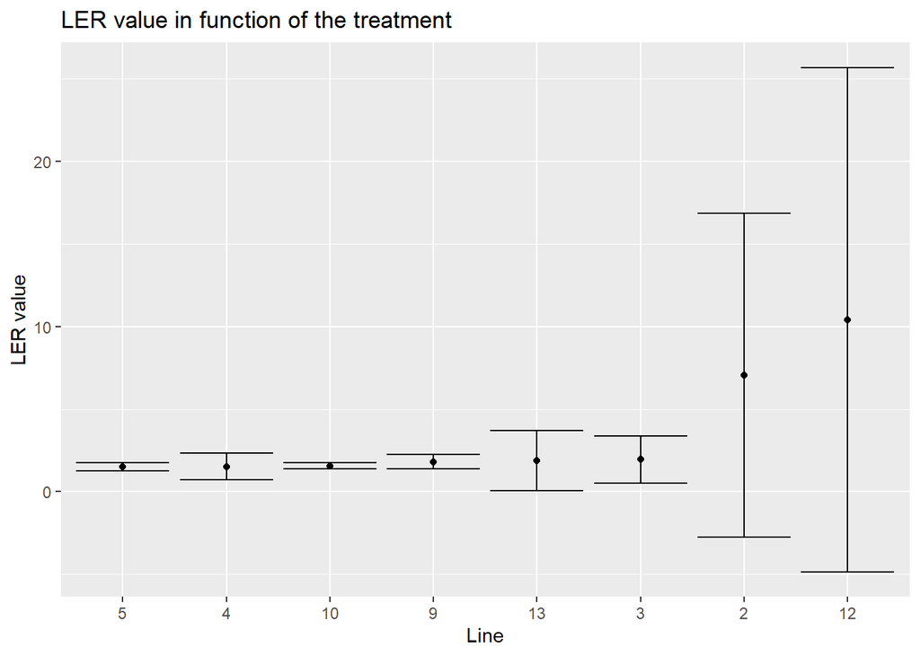

```r
LER%>%
  filter( mono_mix == "mix") %>%
  filter (Specie != "Weed") %>%
  group_by(Line)%>%
  summarise(mymean=mean(LER_cc, na.rm=T),
            mysd=sd(LER_cc, na.rm=T))%>%
  mutate(ymax=mymean+mysd, ymin=mymean-mysd) %>%
  ggplot (aes(x = reorder(Line, mymean), y = mymean,
              ymin=ymin, ymax=ymax, na.rm=T)) +
  geom_point()+
  geom_errorbar()+
  labs(x="Line", y="LER value", title = "LER value in function of the treatment")
```

Test anova sur les LER :

```r
anova.LER <-lm(LER_cc~Line, LER)
anova(anova.LER)
```

|  | Df | Sum Sq | Mean Sq | F value | Pr(>F) |
| --- | --- | --- | --- | --- | --- |
| Line | 1 | 4.778835 | 4.778835 | 0.1162128 | 0.736413 |
| Residuals | 22 | 904.670912 | 41.121405 | NA | NA |

not significative difference between the treatments

vérification des hypothèses de l’anova :

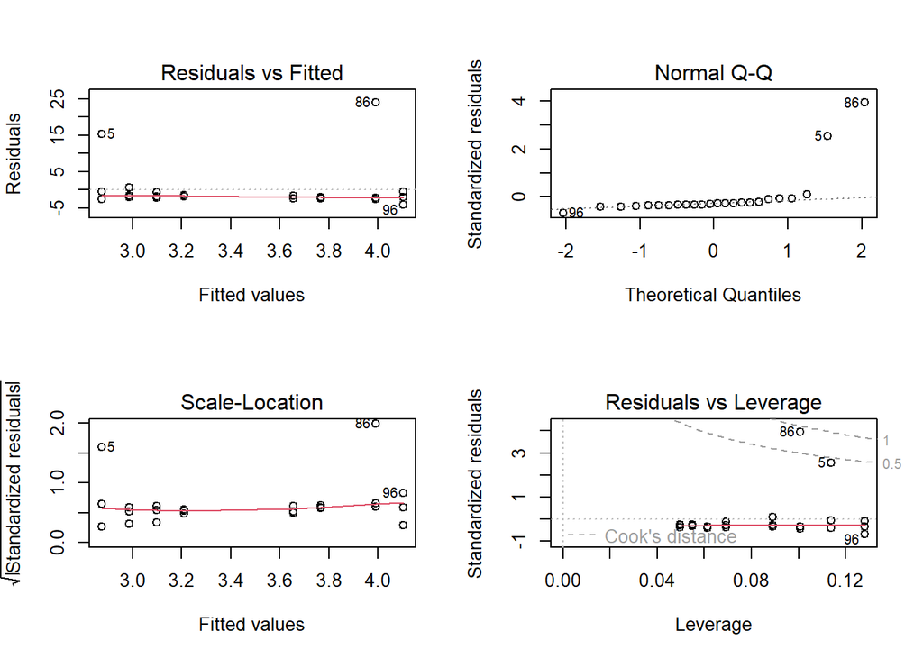

```r
par(mfrow = c(2,2))
plot(anova.LER)
```

==> les points 5 et 86 sont trop différents des autres valeurs, on va les enlever

nouveau tableau sans les lignes 5 et 86 :

```r
LER_best <- LER %>%
  rownames_to_column("observation")%>%
  filter (observation != 86)%>%
  filter( observation != 5)
```

nouveau graphique :

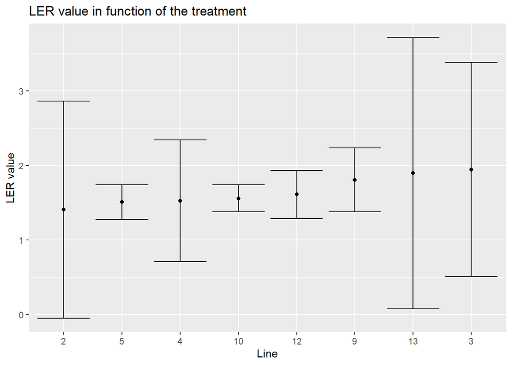

```r
LER_best%>%
  filter( mono_mix == "mix") %>%
  filter (Specie != "Weed") %>%
  group_by(Line)%>%
  summarise(mymean=mean(LER_cc, na.rm=T),
            mysd=sd(LER_cc, na.rm=T))%>%
  mutate(ymax=mymean+mysd, ymin=mymean-mysd) %>%
  ggplot (aes(x = reorder(Line, mymean), y = mymean,
              ymin=ymin, ymax=ymax, na.rm=T)) +
  geom_point()+
  geom_errorbar()+
  labs(x="Line", y="LER value", title = "LER value in function of the treatment")
```

test avec une anova et vérification des hypothèses

```r
anova.LER.best <-lm(LER_cc~Line, LER_best)
anova(anova.LER.best)
```

|  | Df | Sum Sq | Mean Sq | F value | Pr(>F) |
| --- | --- | --- | --- | --- | --- |
| Line | 1 | 0.07162851 | 0.07162851 | 0.09233358 | 0.7643699 |
| Residuals | 20 | 15.51515845 | 0.77575792 | NA | NA |

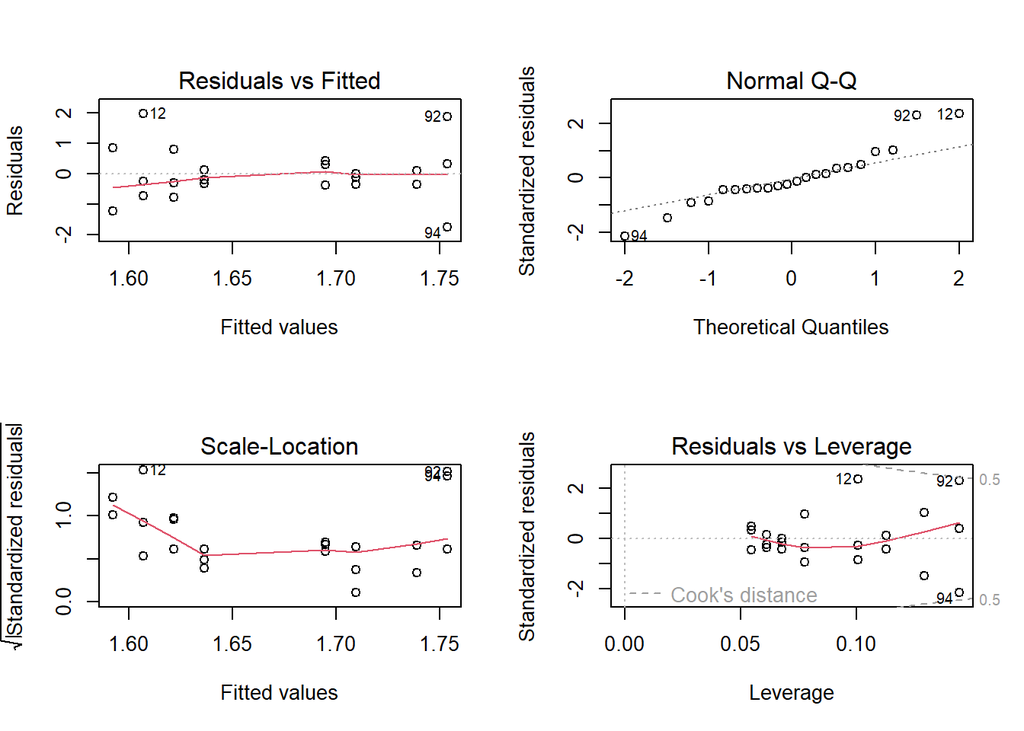

```r
par(mfrow = c(2,2))
plot(anova.LER.best)
```

### Analysis of the LERp for each specie between mix and monoculture

#### Radish

graphique du LERp entre tous les différents treatments où il y a du radis (mono ou mix)

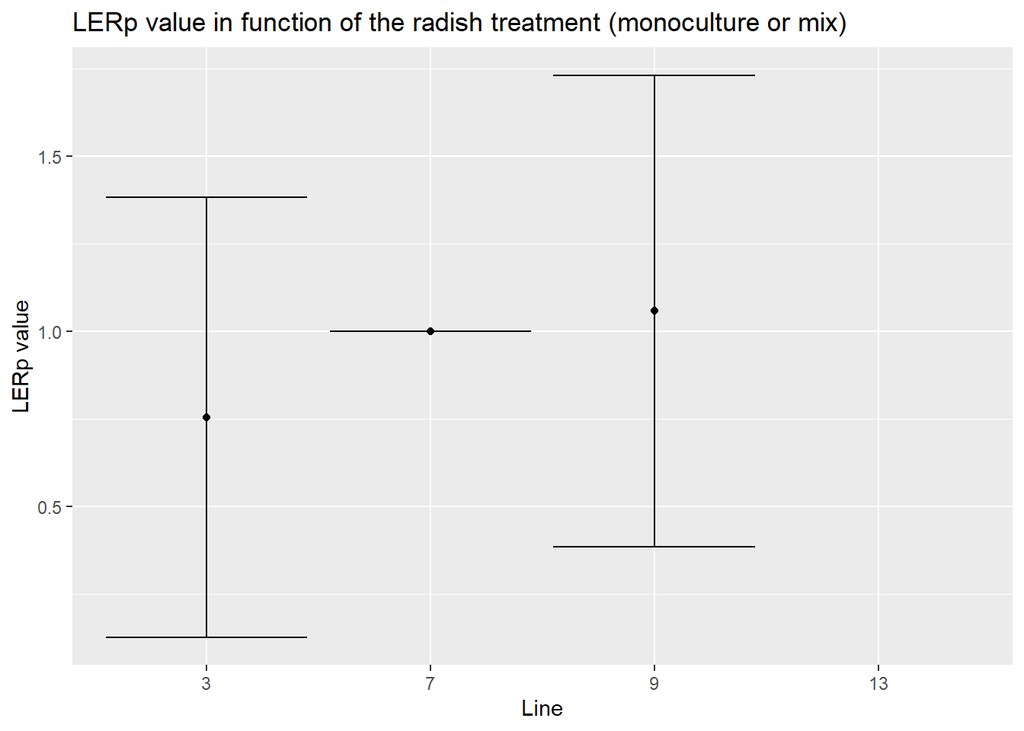

```r
LER%>%
  filter( Specie == "Radish") %>%
  group_by(Line)%>%
  summarise(mymean=mean(LERp, na.rm=T),
            mysd=sd(LERp, na.rm=T))%>%
  mutate(ymax=mymean+mysd, ymin=mymean-mysd) %>%
  ggplot (aes(x = reorder(Line, mymean), y = mymean,
              ymin=ymin, ymax=ymax, na.rm=T)) +
  geom_point()+
  geom_errorbar()+
  labs(x="Line", y="LERp value", title = "LERp value in function of the radish treatment (monoculture or mix)")
```

commentaire : la ligne 13 c’est un mélange avec le radis qui n’a pas marché du tout la ligne 7 c’est le radis en monoculture ==> normal qu’il n’y ai pas de variation ==> LERp=1

test avec une anova :

```r
LER.radish <- LER%>%
  filter( Specie == "Radish")
anova.LER.radish <-lm(LERp~Line,LER.radish)
anova(anova.LER.radish)
```

|  | Df | Sum Sq | Mean Sq | F value | Pr(>F) |
| --- | --- | --- | --- | --- | --- |
| Line | 1 | 0.151885 | 0.151885 | 0.6249922 | 0.4551429 |
| Residuals | 7 | 1.701133 | 0.243019 | NA | NA |

pas de différence significative entre les treatments

vérifier les hypothèses de l’anova :

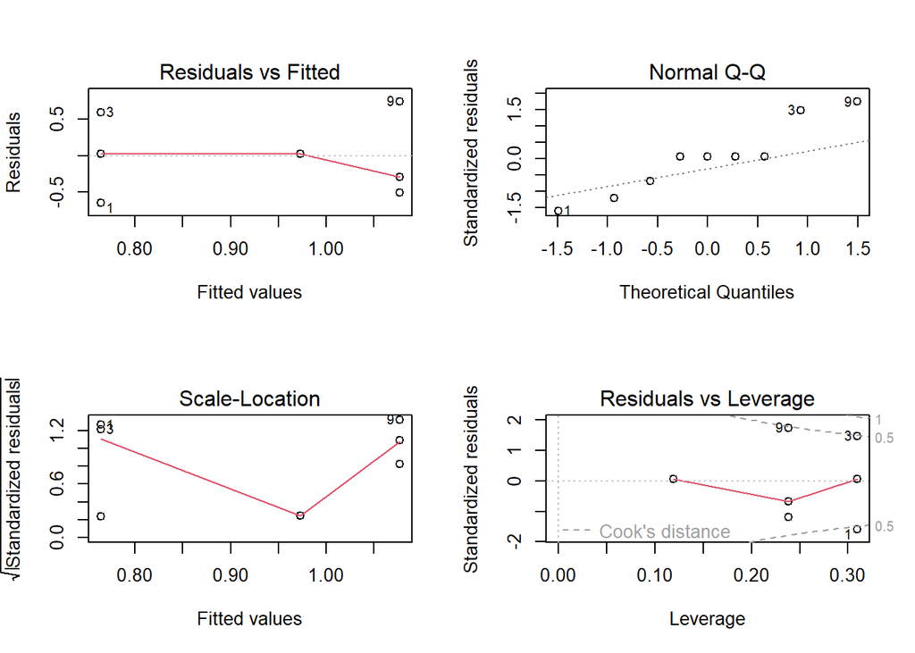

```r
par(mfrow = c(2,2))
plot(anova.LER.radish)
```

Pas ouff; la normalité est pas du tout respecté, on a vraiment très peu de valeurs pour le coup

test d’un kruskal

```r
kruskal.radish <- kruskal(LER.radish$LERp, LER.radish$Line, console = T)
```

```
##
## Study: LER.radish$LERp ~ LER.radish$Line
## Kruskal-Wallis test's
## Ties or no Ties
##
## Critical Value: 0.6436782
## Degrees of freedom: 2
## Pvalue Chisq  : 0.7248148
##
## LER.radish$Line,  means of the ranks
##
##   LER.radish.LERp r
## 3        4.333333 3
## 7        6.000000 3
## 9        4.666667 3
##
## Post Hoc Analysis
##
## t-Student: 2.446912
## Alpha    : 0.05
## Minimum Significant Difference: 5.956573
##
## Treatments with the same letter are not significantly different.
##
##   LER.radish$LERp groups
## 7        6.000000      a
## 9        4.666667      a
## 3        4.333333      a
```

ils ne sont pas significativement différents

#### Barley

graphique du LERp de tous les treatment où il y a du barley (mono ou mix)

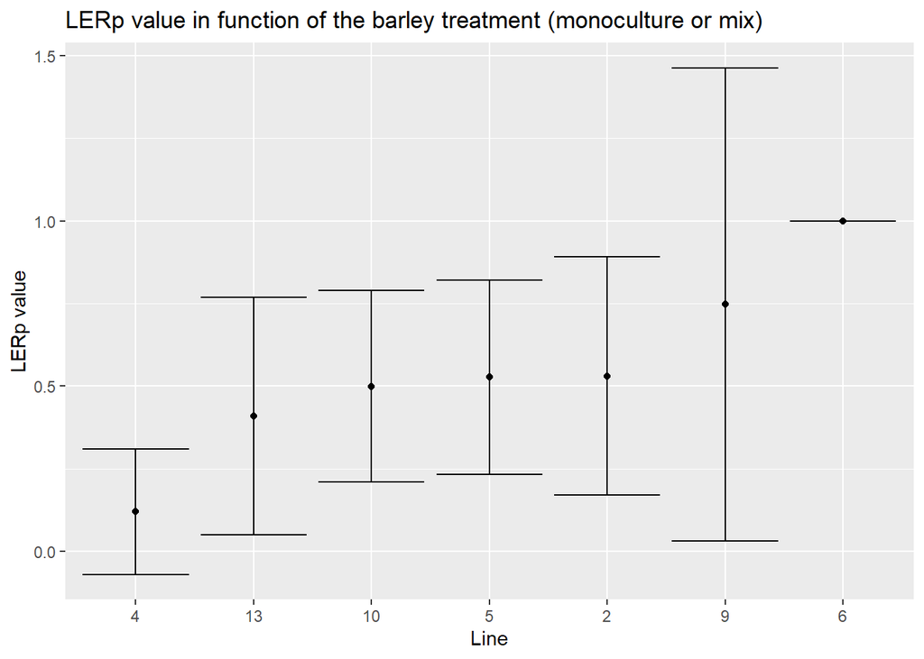

```r
LER%>%
  filter( Specie == "Barley") %>%
  group_by(Line)%>%
  summarise(mymean=mean(LERp, na.rm=T),
            mysd=sd(LERp, na.rm=T))%>%
  mutate(ymax=mymean+mysd, ymin=mymean-mysd) %>%
  ggplot (aes(x = reorder(Line, mymean), y = mymean,
              ymin=ymin, ymax=ymax, na.rm=T)) +
  geom_point()+
  geom_errorbar()+
  labs(x="Line", y="LERp value", title = "LERp value in function of the barley treatment (monoculture or mix)")
```

On peut quand même voir que la plus part des treatments ils sont en dessous de 1 / du controle en ligne 6

anova :

```r
LER.B <- LER%>%
  filter( Specie == "Barley")

anova.LER.B <-lm(LERp~Line,LER.B)
anova(anova.LER.B)
```

|  | Df | Sum Sq | Mean Sq | F value | Pr(>F) |
| --- | --- | --- | --- | --- | --- |
| Line | 1 | 0.004998259 | 0.004998259 | 0.02878831 | 0.8670622 |
| Residuals | 19 | 3.298801689 | 0.173621142 | NA | NA |

pas de différence significative entre les treatments

vérification des hypothèses de l’anova :

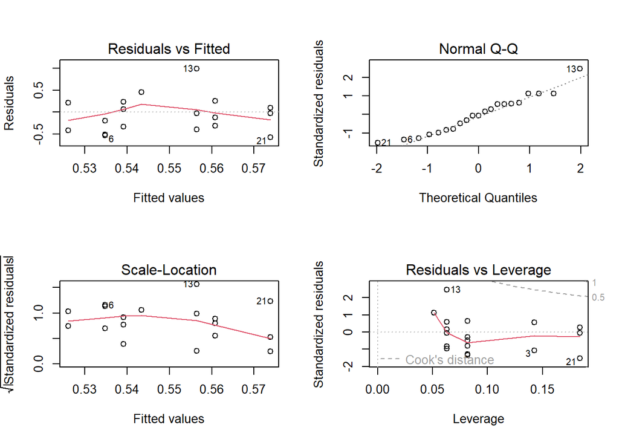

```r
par(mfrow = c(2,2))
plot(anova.LER.B)
```

La normalité est pas ouf, le reste ça passe

test d’un kruskal, j’ai pas le droit mais j’en fait un quand même:

```r
kruskal.B <- kruskal(LER.B$LERp, LER.B$Line, console = T)
```

```
##
## Study: LER.B$LERp ~ LER.B$Line
## Kruskal-Wallis test's
## Ties or no Ties
##
## Critical Value: 9.229099
## Degrees of freedom: 6
## Pvalue Chisq  : 0.1610977
##
## LER.B$Line,  means of the ranks
##
##    LER.B.LERp r
## 2   11.000000 3
## 4    4.166667 3
## 5   11.333333 3
## 6   19.000000 3
## 9   12.000000 3
## 10  11.000000 3
## 13   8.500000 3
##
## Post Hoc Analysis
##
## t-Student: 2.144787
## Alpha    : 0.05
## Minimum Significant Difference: 9.515348
##
## Treatments with the same letter are not significantly different.
##
##    LER.B$LERp groups
## 6   19.000000      a
## 9   12.000000     ab
## 5   11.333333     ab
## 2   11.000000     ab
## 10  11.000000     ab
## 13   8.500000      b
## 4    4.166667      b
```

Les lignes 4 et 13 c’est des mix de 3 espèces ==> pour celà qu’ils sont différents. La ligne 6 c’est le barley en monoculture

#### Mustard

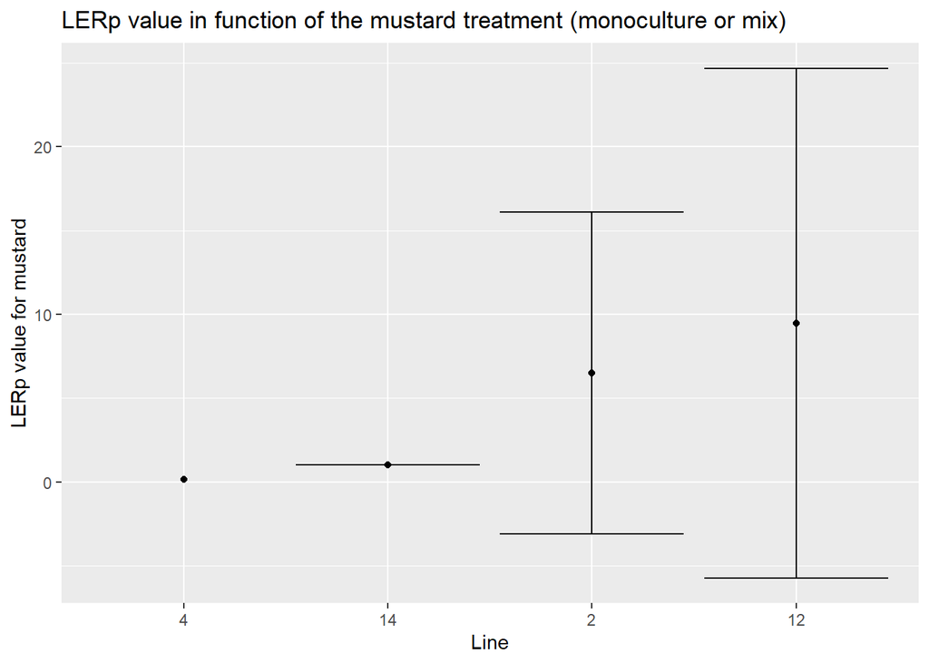

```r
LER%>%
  filter( Specie == "Mustard") %>%
  group_by(Line)%>%
  summarise(mymean=mean(LERp, na.rm=T),
            mysd=sd(LERp, na.rm=T))%>%
  mutate(ymax=mymean+mysd, ymin=mymean-mysd, ) %>%
  ggplot (aes(x = reorder(Line, mymean), y = mymean,
              ymin=ymin, ymax=ymax, na.rm=T)) +
  geom_point()+
  geom_errorbar()+
  labs(x="Line", y="LERp value for mustard", title = "LERp value in function of the mustard treatment (monoculture or mix)")
```

La ligne 14 c’est la moutarde en monoculture La ligne 4 : qu’une seule valeur pour une zone est valables

anova:

```r
LER.m <- LER%>%
  filter( Specie == "Mustard")

anova.LER.m <-lm(LERp~Line,LER.m)
anova(anova.LER.m)
```

|  | Df | Sum Sq | Mean Sq | F value | Pr(>F) |
| --- | --- | --- | --- | --- | --- |
| Line | 1 | 2.646505 | 2.646505 | 0.02707138 | 0.8733922 |
| Residuals | 8 | 782.082156 | 97.760269 | NA | NA |

pas de différence significative vérification des hypothèses

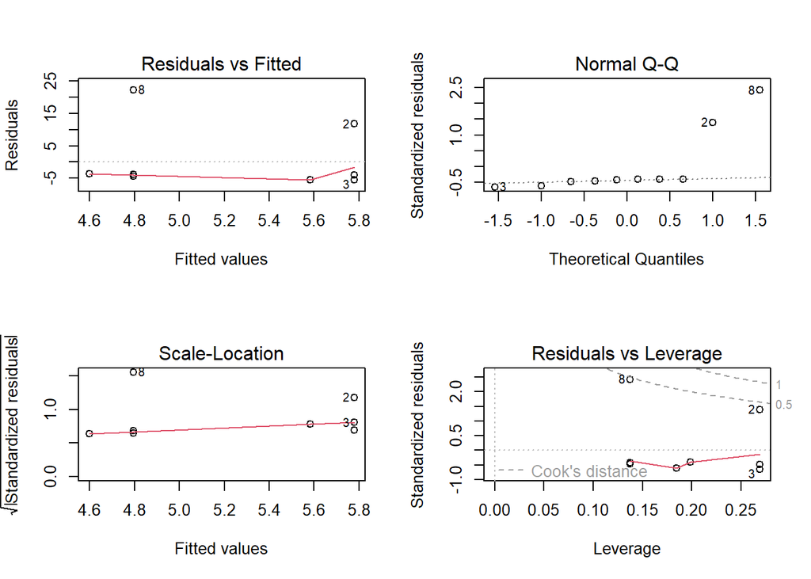

```r
par(mfrow = c(2,2))
plot(anova.LER.m)
```

encore une fois on a vraiment très peu de valeurs dont 2 valeurs qui sont pas ouf (la 2 et la 8)

test sans ces 2 valeurs : ==> en vrai flemme de ouf

#### Faba bean

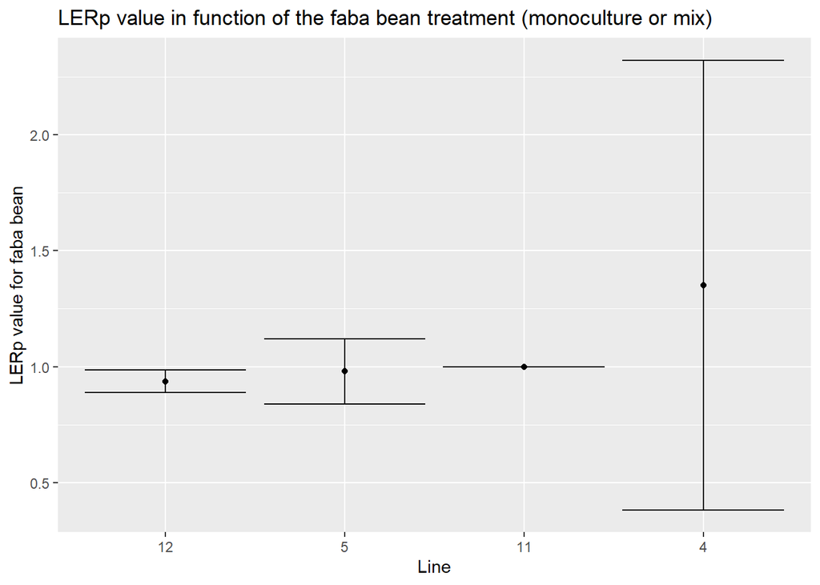

```r
LER%>%
  filter( Specie == "Faba bean") %>%
  group_by(Line)%>%
  summarise(mymean=mean(LERp, na.rm=T),
            mysd=sd(LERp, na.rm=T))%>%
  mutate(ymax=mymean+mysd, ymin=mymean-mysd, ) %>%
  ggplot (aes(x = reorder(Line, mymean), y = mymean,
              ymin=ymin, ymax=ymax, na.rm=T)) +
  geom_point()+
  geom_errorbar()+
  labs(x="Line", y="LERp value for faba bean", title = "LERp value in function of the faba bean treatment (monoculture or mix)")
```

Line 4 : mix of 3 Line 11: Faba bean in monoculture

```r
LER.fb <- LER%>%
  filter( Specie == "Faba bean")

anova.LER.fb <-lm(LERp~Line,LER.fb)
anova(anova.LER.fb)
```

|  | Df | Sum Sq | Mean Sq | F value | Pr(>F) |
| --- | --- | --- | --- | --- | --- |
| Line | 1 | 0.1534899 | 0.1534899 | 0.7301459 | 0.4128383 |
| Residuals | 10 | 2.1021811 | 0.2102181 | NA | NA |

pas de différence significatif

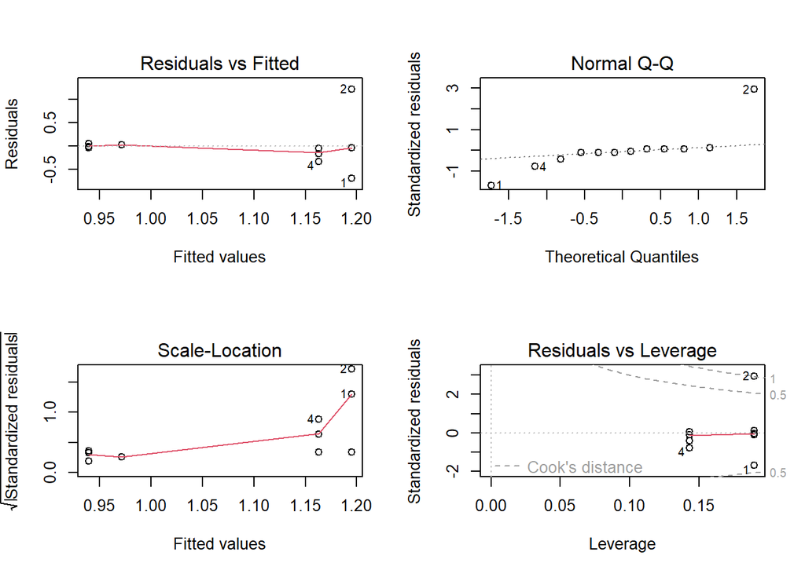

```r
par(mfrow = c(2,2))
plot(anova.LER.fb)
```

Pas ouf mais de toute façon pas énormément de valeurs

#### Fenugreek

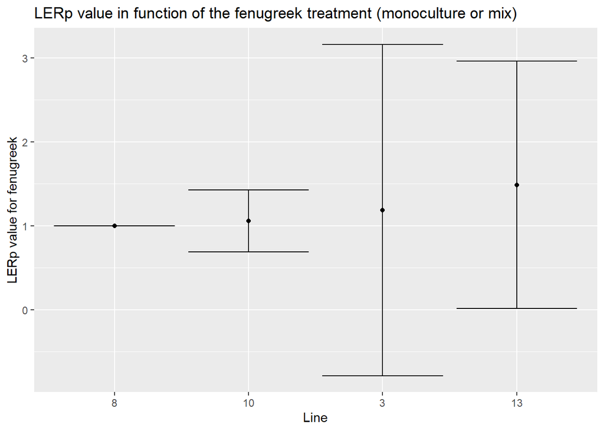

```r
LER%>%
  filter( Specie == "Fenugreek") %>%
  group_by(Line)%>%
  summarise(mymean=mean(LERp, na.rm=T),
            mysd=sd(LERp, na.rm=T))%>%
  mutate(ymax=mymean+mysd, ymin=mymean-mysd, ) %>%
  ggplot (aes(x = reorder(Line, mymean), y = mymean,
              ymin=ymin, ymax=ymax, na.rm=T)) +
  geom_point()+
  geom_errorbar()+
  labs(x="Line", y="LERp value for fenugreek", title = "LERp value in function of the fenugreek treatment (monoculture or mix)")
```

Line 8: monoculture Line 3: mix of 2 Line 13: mix of 3

```r
LER.fn <- LER%>%
  filter( Specie == "Fenugreek")

anova.LER.fn <-lm(LERp~Line,LER.fn)
anova(anova.LER.fn)
```

|  | Df | Sum Sq | Mean Sq | F value | Pr(>F) |
| --- | --- | --- | --- | --- | --- |
| Line | 1 | 0.08627166 | 0.08627166 | 0.06771732 | 0.7999695 |
| Residuals | 10 | 12.73997043 | 1.27399704 | NA | NA |

pas de différence significative

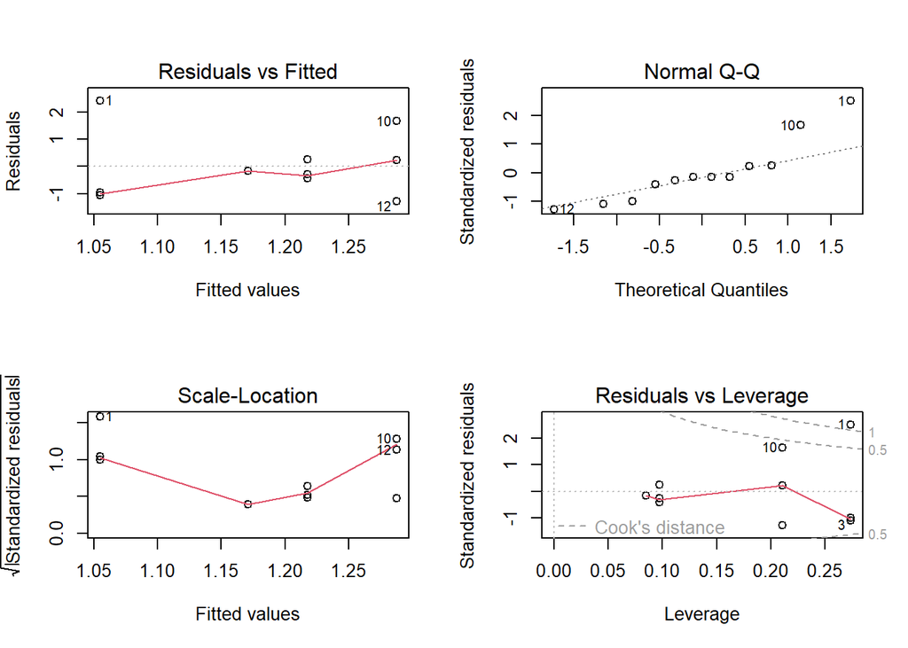

```r
par(mfrow = c(2,2))
plot(anova.LER.fn)
```

pas ouf

## Spad analysis

### importation of the data and pivot :

```r
spad_ini= read.table("4_spad.csv", header = TRUE,sep = ";", dec = ",")

spad_ini%>%
  mutate(Line = as.integer(Line), nature=as.factor(nature),
         legumes=as.factor(legumes), Date=as.factor(Date))
```

| Date | Line | Specie | nature | legumes | Z1 | Z1.1 | Z1.2 | Z1.3 | Z1.4 | Z2 | Z2.1 | Z2.2 | Z2.3 | Z2.4 | Z3 | Z3.1 | Z3.2 | Z3.3 | Z3.4 |
| --- | --- | --- | --- | --- | --- | --- | --- | --- | --- | --- | --- | --- | --- | --- | --- | --- | --- | --- | --- |
| 17/10 | 2 | Barley | mix | no | 101.4 | 63.9 | 97.9 | 53.4 | 42.9 | 63.7 | 101.0 | 99.4 | 101.0 | 95.9 | 25.2 | 38.3 | 47.3 | 35.7 | 44.1 |
| 17/10 | 2 | Mustard | mix | no | 35.7 | 58.3 | 36.5 | 36.8 | 35.6 | 31.2 | 29.3 | 29.2 | 28.0 | 31.6 | 29.3 | 28.9 | 30.3 | 29.2 | 28.8 |
| 17/10 | 3 | Radish | mix | yes | 36.9 | 36.2 | 34.7 | 34.3 | 33.8 | 35.1 | 31.1 | 33.4 | 33.5 | 33.1 | 27.2 | 26.4 | 26.7 | 31.6 | 25.6 |
| 17/10 | 3 | Fenugreek | mix | yes | 47.4 | 49.1 | 54.0 | 47.4 | 47.6 | 46.7 | 44.4 | 45.3 | 45.1 | 45.8 | 43.1 | 42.9 | 37.8 | 43.5 | 44.2 |
| 17/10 | 4 | Barley | mix | yes | 34.9 | 36.6 | 39.3 | NA | 39.3 | 87.3 | 38.4 | 96.6 | 82.0 | 58.6 | 27.0 | 29.4 | 31.6 | 28.6 | 30.0 |
| 17/10 | 4 | Faba bean | mix | yes | 42.5 | 44.9 | 44.1 | 44.1 | 44.8 | 38.1 | 52.4 | 40.2 | 51.5 | 50.1 | 66.2 | 43.3 | 43.2 | 45.6 | 43.4 |
| 17/10 | 4 | Mustard | mix | yes | 41.5 | 39.3 | 34.6 | 34.4 | 35.4 | 32.2 | 36.9 | 33.3 | 32.6 | 34.2 | 20.1 | 31.8 | 31.5 | 31.5 | 31.7 |
| 17/10 | 5 | Barley | mix | yes | 34.3 | 44.6 | 42.3 | 41.2 | 36.9 | 37.9 | 39.6 | 37.3 | 37.4 | 37.4 | 40.8 | 41.1 | 41.0 | 41.1 | 41.2 |
| 17/10 | 5 | Faba bean | mix | yes | 41.1 | 41.6 | 43.0 | 41.8 | 42.0 | 35.6 | 47.2 | 37.7 | 36.3 | 35.8 | 43.7 | 41.0 | 38.5 | 41.7 | 41.8 |
| 17/10 | 6 | Barley | mono | no | 43.0 | 40.8 | 41.9 | 39.4 | 41.4 | 52.7 | 114.3 | 94.4 | 101.8 | 92.8 | 31.5 | 37.3 | 35.6 | 36.5 | 36.3 |

[output cut: 36 more lines]

```r
spad <- spad_ini %>%
  pivot_longer(cols = Z1:Z3.4,
               names_to = "zone", values_to = "spad_value" )
spad%>%
  na.omit()
```

| Date | Line | Specie | nature | legumes | zone | spad_value |
| --- | --- | --- | --- | --- | --- | --- |
| 17/10 | 2 | Barley | mix | no | Z1 | 101.4 |
| 17/10 | 2 | Barley | mix | no | Z1.1 | 63.9 |
| 17/10 | 2 | Barley | mix | no | Z1.2 | 97.9 |
| 17/10 | 2 | Barley | mix | no | Z1.3 | 53.4 |
| 17/10 | 2 | Barley | mix | no | Z1.4 | 42.9 |
| 17/10 | 2 | Barley | mix | no | Z2 | 63.7 |
| 17/10 | 2 | Barley | mix | no | Z2.1 | 101.0 |
| 17/10 | 2 | Barley | mix | no | Z2.2 | 99.4 |
| 17/10 | 2 | Barley | mix | no | Z2.3 | 101.0 |
| 17/10 | 2 | Barley | mix | no | Z2.4 | 95.9 |

[output cut: 671 more lines]

We have a problem for the zones because the zones 1 don’t have the same name

### spad analysis for the first date

#### For all the treatments

```r
spad.1 <- spad%>%
  filter( Date == "17/10")
```

test anova

```r
anova.spad.all <-lm(spad_value~Line,spad.1)
anova(anova.spad.all)
```

|  | Df | Sum Sq | Mean Sq | F value | Pr(>F) |
| --- | --- | --- | --- | --- | --- |
| Line | 1 | 3614.559 | 3614.559 | 19.1292 | 1.634544e-05 |
| Residuals | 334 | 63110.981 | 188.955 | NA | NA |

anova significative !!!!

vérification des hypothèses de l’anova:

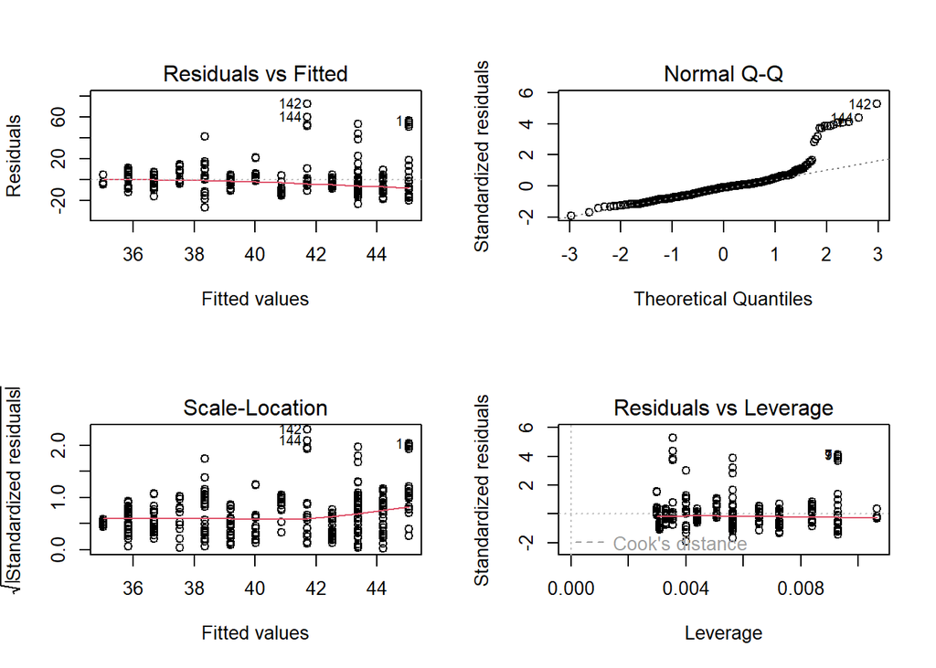

```r
par(mfrow = c(2,2))
plot(anova.spad.all)
```

hypothèse de normalité pas incroyable ==> est ce qu’on peut vraiment faire une anova?

test de kruskal:

```r
kruskal.spad.all <- kruskal(spad.1$spad_value, spad.1$Line, console = T)
```

```
##
## Study: spad.1$spad_value ~ spad.1$Line
## Kruskal-Wallis test's
## Ties or no Ties
##
## Critical Value: 59.84716
## Degrees of freedom: 12
## Pvalue Chisq  : 2.406872e-08
##
## spad.1$Line,  means of the ranks
##
##    spad.1.spad_value  r
## 2          178.63333 30
## 3          176.61667 30
## 4          178.78409 44
## 5          198.96667 30
## 6          223.50000 15
## 7           74.93333 15
## 8          251.36667 15
## 9          134.15000 30
## 10         185.77778 27
## 11         233.53571 14
## 12         142.14286 28
## 13         146.12500 44
## 14          82.60714 14
##
## Post Hoc Analysis
##
## t-Student: 1.967336
## Alpha    : 0.05
## Groups according to probability of treatment differences and alpha level.
##
## Treatments with the same letter are not significantly different.
##
##    spad.1$spad_value groups
## 8          251.36667      a
## 11         233.53571     ab
## 6          223.50000    abc
## 5          198.96667    abc
## 10         185.77778    bcd
## 4          178.78409     cd
## 2          178.63333    cde
## 3          176.61667    cde
## 13         146.12500     de
## 12         142.14286     de
## 9          134.15000     ef
## 14          82.60714     fg
## 7           74.93333      g
```

graph with the letters of the kruskal

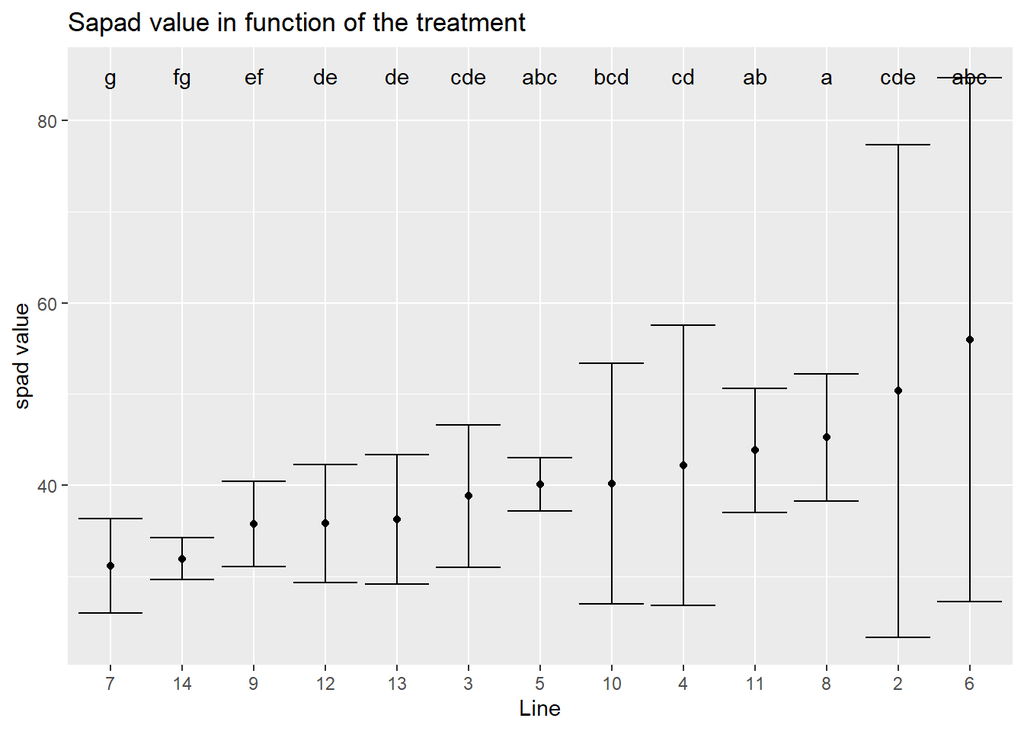

```r
posthock.spad.all <- kruskal.spad.all$groups %>%
  rownames_to_column("Line") %>%
  select(Line, groups)%>%
  mutate(Line= as.integer(Line))

spad.1%>%
  group_by(Line)%>%
  summarise(mymean=mean(spad_value, na.rm=T),
            mysd=sd(spad_value, na.rm=T))%>%
  mutate(ymax=mymean+mysd, ymin=mymean-mysd) %>%
  full_join(posthock.spad.all)%>%
  ggplot (aes(x = reorder(Line, mymean), y = mymean, label = groups,
              ymin=ymin, ymax=ymax, na.rm=T)) +
  geom_point()+
  geom_text(aes(y=85))+
  geom_errorbar()+
  labs(x="Line", y="spad value", title = "Sapad value in function of the treatment")
```

tukey because anova is great ??

```r
# tukey.spad.all.1 <- HSD.test(spad.1, "Line", alpha=0.05, group=TRUE, main = NULL, console = FALSE)
# print(tukey.spad.all.1)
# posthock.spad.all.2 <- tukey.spad.all.1%>%
#   rownames_to_column("Line")%>%
#   select(Line, groups)
#
# view(posthock.spad.all.2)
```

Il est possible de faire la même chose pour les espèces séparément entre les monoculture et les mixes #### For barley #### For mustard #### Radish #### For Faba bean #### Fenugreek

### Spad analysis for the second date

je ne vait pas le faire c’est juste un copier coller

```r
spad.2 <- spad%>%
  filter( Date == "07/11")
```

test anova

```r
anova.spad.all.2 <-lm(spad_value~Line,spad.2)
anova(anova.spad.all.2)
```

|  | Df | Sum Sq | Mean Sq | F value | Pr(>F) |
| --- | --- | --- | --- | --- | --- |
| Line | 1 | 879.9288 | 879.92878 | 10.06956 | 0.001643689 |
| Residuals | 343 | 29973.0708 | 87.38505 | NA | NA |

anova significative

vérification des hypothèses :

[figure not shown]

```r
par(mfrow = c(2,2))
plot(anova.spad.all)
```

la normalité est pas dingue

test de kruskal:

```r
kruskal.spad.all.2 <- kruskal(spad.2$spad_value, spad.2$Line, console = T)
```

```
##
## Study: spad.2$spad_value ~ spad.2$Line
## Kruskal-Wallis test's
## Ties or no Ties
##
## Critical Value: 68.58962
## Degrees of freedom: 12
## Pvalue Chisq  : 5.874999e-10
##
## spad.2$Line,  means of the ranks
##
##    spad.2.spad_value  r
## 2           150.9833 30
## 3           125.6500 30
## 4           151.1444 45
## 5           220.6667 30
## 6           167.5667 15
## 7           143.9667 15
## 8           295.7000 15
## 9           108.6167 30
## 10          216.0333 30
## 11          211.3333 15
## 12          138.2833 30
## 13          197.8222 45
## 14          193.0667 15
##
## Post Hoc Analysis
##
## t-Student: 1.967135
## Alpha    : 0.05
## Groups according to probability of treatment differences and alpha level.
##
## Treatments with the same letter are not significantly different.
##
##    spad.2$spad_value groups
## 8           295.7000      a
## 5           220.6667      b
## 10          216.0333      b
## 11          211.3333      b
## 13          197.8222      b
## 14          193.0667     bc
## 6           167.5667    bcd
## 4           151.1444     cd
## 2           150.9833    cde
## 7           143.9667    cde
## 12          138.2833    cde
## 3           125.6500     de
## 9           108.6167      e
```

graph with letters of the kruskal

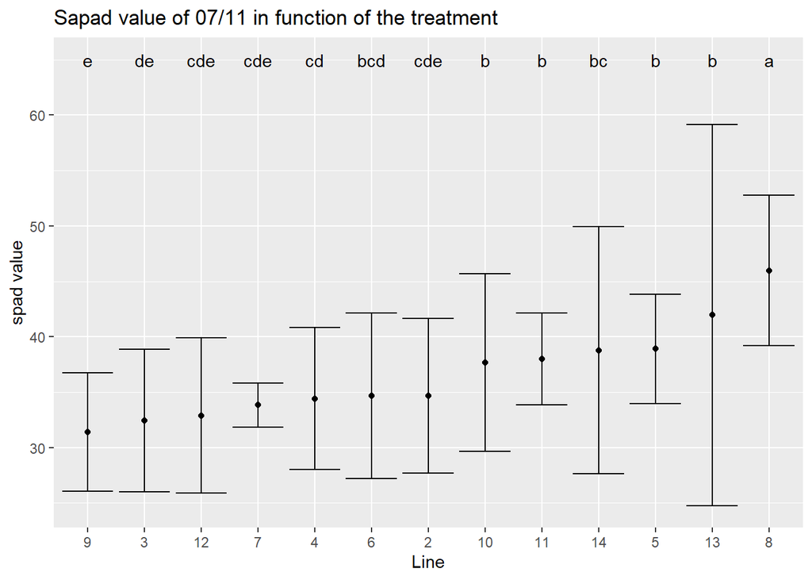

```r
posthock.spad.all.2 <- kruskal.spad.all.2$groups %>%
  rownames_to_column("Line") %>%
  select(Line, groups)%>%
  mutate(Line= as.integer(Line))

spad.2%>%
  group_by(Line)%>%
  summarise(mymean=mean(spad_value, na.rm=T),
            mysd=sd(spad_value, na.rm=T))%>%
  mutate(ymax=mymean+mysd, ymin=mymean-mysd) %>%
  full_join(posthock.spad.all.2)%>%
  ggplot (aes(x = reorder(Line, mymean), y = mymean, label = groups,
              ymin=ymin, ymax=ymax, na.rm=T)) +
  geom_point()+
  geom_text(aes(y=65))+
  geom_errorbar()+
  labs(x="Line", y="spad value", title = "Sapad value of 07/11 in function of the treatment")
```

### Spad analysis of the impact of the legume and the mix or monoculture effect

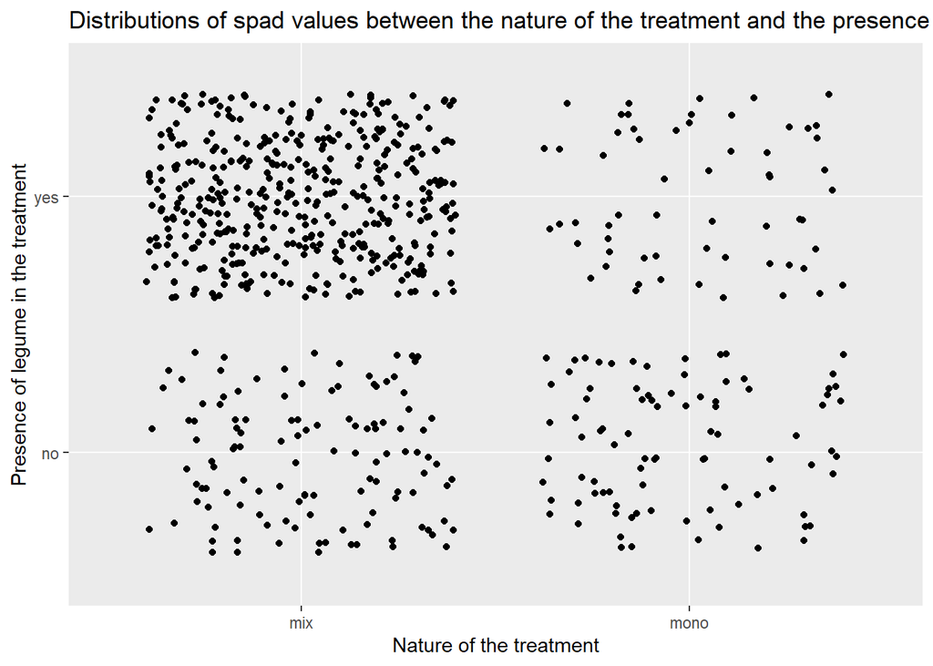

```r
spad%>%
  group_by(Line)%>%
  ggplot (aes(x = nature, y = legumes, na.rm=T)) +
  geom_jitter()+
  labs(x="Nature of the treatment", y="Presence of legume in the treatment", title = "Distributions of spad values between the nature of the treatment and the presence or not of legumes in the treatment")
```

test statistique

```r
anova.spad.legumes.mix <-lm(spad$spad_value~spad$nature+spad$legumes+spad$nature*spad$legumes, spad)
anova(anova.spad.legumes.mix)
```

|  | Df | Sum Sq | Mean Sq | F value | Pr(>F) |
| --- | --- | --- | --- | --- | --- |
| spad$nature | 1 | 528.2625 | 528.2625 | 3.627541 | 0.05725429 |
| spad$legumes | 1 | 219.7980 | 219.7980 | 1.509337 | 0.21966714 |
| spad$nature:spad$legumes | 1 | 842.8689 | 842.8689 | 5.787920 | 0.01640378 |
| Residuals | 677 | 98588.4870 | 145.6255 | NA | NA |